# Projeto de Estudo - Data Analysis

#### Construindo um Bublemap usando folium

```python
# Função para add cores
def color_circles(val):
    if val <= city[item].quantile(.25):
        return 'forestgreen'
    elif val <= city[item].quantile(.50):
        return 'goldenrod'
    elif val <= city[item].quantile(.75):
        return 'Tomato'
    else:
        return 'darkred'
```

```python
legenda_mapa = """
{% macro html(this,kwargs) %}

<div style = "position: fixed;
top: 10px;
bottom: 10px;
right: 10px;
width: 280px;
height: 120px;
font-size: 14px;
z-index: 9999;
opacity: 0.7;
border: 2px solid grey;
border-radius: 12px;
">
<p><a style= "color:black; margin-left: 20px;margin-top:20px"></a><b>Legenda</b></p>
<a style= "color:forestgreen; margin-left: 20px;">&FilledSmallSquare;</a>Até 25% do Range  de Valores
<a style= "color:goldenrod; margin-left: 20px;">&FilledSmallSquare;</a>Até 50% do Range  de Valores
<a style= "color:Tomato; margin-left: 20px;">&FilledSmallSquare;</a>Até 75% do Range  de Valores
<p><a style= "color:darkred; margin-left: 20px;">&FilledSmallSquare;</a>Acima de 75% do Range  de Valores</p>

</div>
<div style = "position: fixed;
top: 10px;
right: 10px;
width: 280px;
height: 120px;
font-size: 14px;
background-color: white;
z-index: 9998;
opacity: 0.7;
border: 2px solid grey;
border-radius: 12px;
">
</div>

{% endmacro %}
"""

legenda = branca.element.MacroElement()
legenda._template = branca.element.Template(legenda_mapa)
```

```python
# plot Análise geoespacial 1
map = f.Map(location=[city['latitude'].mean(),
                      city['longitude'].mean()],
            tiles="cartodb positron",
            zoom_start=2)

item = top_range[0]

for i in range(0, len(city)):
    f.Circle(location = [city.iloc[i]['latitude'], city.iloc[i]['longitude']],
           radius=120000,
           color=color_circles(city.iloc[i][item])).add_to(map)
map.add_child(legenda)
print('Preço médio da ',item)
map
```

```
Preço médio da  estilo_vida
```

Make this Notebook Trusted to load map: File -> Trust Notebook

[interactive chart not shown]

```python
# plot Análise geoespacial 1
map = f.Map(location=[city['latitude'].mean(),
                      city['longitude'].mean()],
            tiles="cartodb positron",
            zoom_start=2)

item = top_range[1]

for i in range(0, len(city)):
    f.Circle(location = [city.iloc[i]['latitude'], city.iloc[i]['longitude']],
           radius=120000,
           color=color_circles(city.iloc[i][item])).add_to(map)
map.add_child(legenda)
print('Preço médio da ',item)
map
```

```
Preço médio da  alimento
```

Make this Notebook Trusted to load map: File -> Trust Notebook

[interactive chart not shown]

```python
# plot Análise geoespacial 1
map = f.Map(location=[city['latitude'].mean(),
                      city['longitude'].mean()],
            tiles="cartodb positron",
            zoom_start=2)

item = top_range[2]

for i in range(0, len(city)):
    f.Circle(location = [city.iloc[i]['latitude'], city.iloc[i]['longitude']],
           radius=120000,
           color=color_circles(city.iloc[i][item])).add_to(map)
map.add_child(legenda)
print('Preço médio da ',item)
map
```

```
Preço médio da  moradia
```

Make this Notebook Trusted to load map: File -> Trust Notebook

[interactive chart not shown]

```python
# plot Análise geoespacial 1
map = f.Map(location=[city['latitude'].mean(),
                      city['longitude'].mean()],
            tiles="cartodb positron",
            zoom_start=2)

item = top_range[3]

for i in range(0, len(city)):
    f.Circle(location = [city.iloc[i]['latitude'], city.iloc[i]['longitude']],
           radius=120000,
           color=color_circles(city.iloc[i][item])).add_to(map)
map.add_child(legenda)
print('Preço médio da ',item)
map
```

```
Preço médio da  renda
```

Make this Notebook Trusted to load map: File -> Trust Notebook

[interactive chart not shown]

```python
# plot Análise geoespacial 1
map = f.Map(location=[city['latitude'].mean(),
                      city['longitude'].mean()],
            tiles="cartodb positron",
            zoom_start=2)

item = top_range[4]

for i in range(0, len(city)):
    f.Circle(location = [city.iloc[i]['latitude'], city.iloc[i]['longitude']],
           radius=120000,
           color=color_circles(city.iloc[i][item])).add_to(map)
map.add_child(legenda)
print('Preço médio da ',item)
map
```

```
Preço médio da  educacao
```

Make this Notebook Trusted to load map: File -> Trust Notebook

[interactive chart not shown]

```python
# plot Análise geoespacial 1
map = f.Map(location=[city['latitude'].mean(),
                      city['longitude'].mean()],
            tiles="cartodb positron",
            zoom_start=2)

item = top_range[5]

for i in range(0, len(city)):
    f.Circle(location = [city.iloc[i]['latitude'], city.iloc[i]['longitude']],
           radius=120000,
           color=color_circles(city.iloc[i][item])).add_to(map)
map.add_child(legenda)
print('Preço médio da ',item)
map
```

```
Preço médio da  viagem
```

Make this Notebook Trusted to load map: File -> Trust Notebook

[interactive chart not shown]

#### Correlação entre as classes

Podemos verificar que países que possuem uma maior renda tem uma correlação maior com o custo de alimentos e viagens.

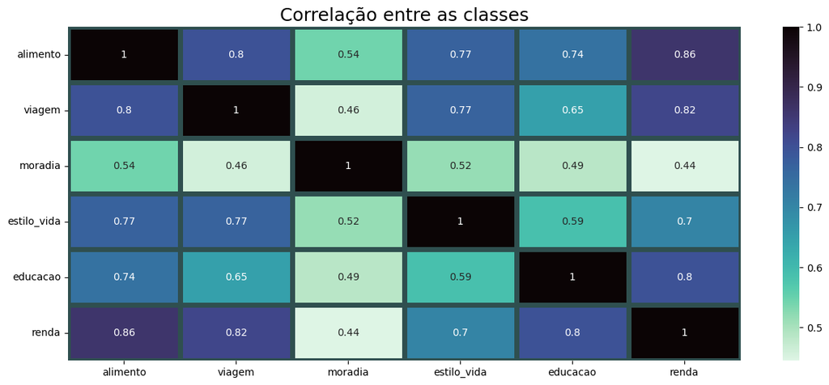

```python
correlation = df_1.iloc[:,1:7].corr()
plt.figure(figsize=(15,6))
sns.heatmap(correlation, cmap='mako_r', annot=True, linewidths=5, linecolor='DarkSlateGray')
plt.title('Correlação entre as classes', size=18)
plt.yticks(rotation='horizontal')
plt.show()
```

### Verificando custo de regiões pesquisadas dentro de um determinado país.

Selecionamos os Estados Unidos por possuir, neste conjunto de dados, mais registros para demonstração

Se você pulou a etapa acima, realize a execução agora deste código para separa as regiões dos estados unidos

```python
df_2 = city.copy()
df_2 = df_2[['alimento','viagem','moradia','estilo_vida','educacao','renda','latitude','longitude','Cities','Countries']]
df_2.head()
```

|  | alimento | viagem | moradia | estilo_vida | educacao | renda | latitude | longitude | Cities | Countries |
| --- | --- | --- | --- | --- | --- | --- | --- | --- | --- | --- |
| 0 | 2 | 8 | 5019 | 34 | 2900 | 328 | 59.938732 | 30.316229 | Saint Petersburg, Russia | Russia |
| 1 | 2 | 6 | 5408 | 22 | 3594 | 227 | 41.006381 | 28.975872 | Istanbul, Turkey | Turkey |
| 2 | 2 | 4 | 5297 | 19 | 2580 | 207 | 38.423743 | 27.142802 | Izmir, Turkey | Turkey |
| 3 | 4 | 19 | 6984 | 44 | 996 | 1191 | 60.167488 | 24.942747 | Helsinki, Finland | Finland |
| 4 | 1 | 2 | 4040 | 31 | 1444 | 148 | 47.024512 | 28.832292 | Chisinau, Moldova | Moldova |

```python
# Consertando coluna paises
lista = []
for c in df_2['Countries']:
    if len(c) < 3:
        lista.append('United States')
    else:
        lista.append(c)
df_2['Countries'] = lista
usa = df_2[df_2['Countries'] == 'United States']
usa.head(2)
```

|  | alimento | viagem | moradia | estilo_vida | educacao | renda | latitude | longitude | Cities | Countries |
| --- | --- | --- | --- | --- | --- | --- | --- | --- | --- | --- |
| 38 | 4 | 11 | 5712 | 36 | 9214 | 2051 | 30.271129 | -97.743700 | Austin, TX, United States | United States |
| 47 | 5 | 18 | 6810 | 40 | 13088 | 2068 | 42.355433 | -71.060511 | Boston, MA, United States | United States |

```python
cidade = []
estado = []

for item in usa['Cities']:
    separados = item.split(', ')
    cidade.append(separados[0])
    estado.append(separados[1])

usa['Cities'] = cidade
usa['States'] = estado
usa.drop('Countries', axis=1)
# organizando dataframe
usa = usa[['Cities','States','latitude','longitude','alimento','viagem','moradia','estilo_vida','educacao','renda']]

usa.head()
```

|  | Cities | States | latitude | longitude | alimento | viagem | moradia | estilo_vida | educacao | renda |
| --- | --- | --- | --- | --- | --- | --- | --- | --- | --- | --- |
| 38 | Austin | TX | 30.271129 | -97.743700 | 4 | 11 | 5712 | 36 | 9214 | 2051 |
| 47 | Boston | MA | 42.355433 | -71.060511 | 5 | 18 | 6810 | 40 | 13088 | 2068 |
| 48 | Chicago | IL | 41.875562 | -87.624421 | 4 | 20 | 5774 | 40 | 8499 | 1860 |
| 53 | Dallas | TX | 32.776272 | -96.796856 | 4 | 18 | 4989 | 35 | 8845 | 2103 |
| 62 | Houston | TX | 29.758938 | -95.367697 | 4 | 11 | 5339 | 35 | 9784 | 1786 |

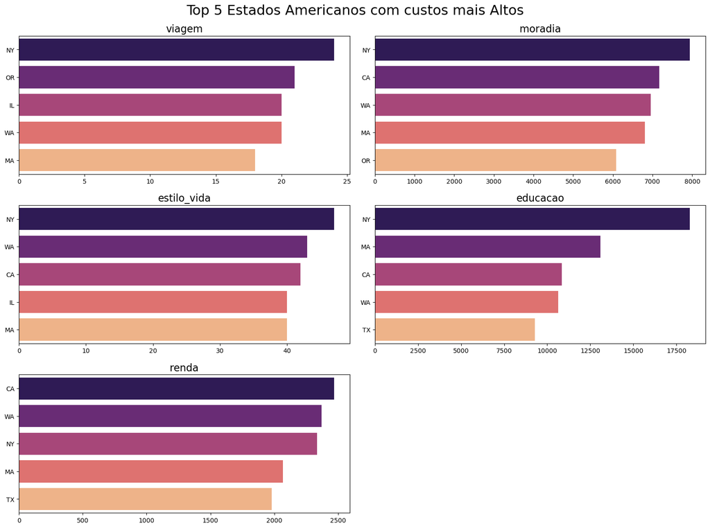

```python
# Gráficos - Top 5 países com maiores custos médios por categoria
colunas = usa.columns[5:]
plt.figure(figsize=(16,12))
plt.suptitle('Top 5 Estados Americanos com custos mais Altos', size=22)

for n, col in enumerate(colunas):
    plt.subplot(3,2,n+1)
    current_df = usa[['States',col]].groupby('States').agg('mean').sort_values(by=col, ascending=False).reset_index().head(5)
    sns.barplot(y=current_df['States'].head(5), x=current_df[col], hue=current_df['States'].head(5), palette='magma')
    plt.ylabel(None)
    plt.xlabel(None)
    plt.title(col, size=16)
plt.tight_layout(pad=1.4)
plt.show()
```

Observação: A categoria RENDA não e um custo, é um provendo (média de ganhos)

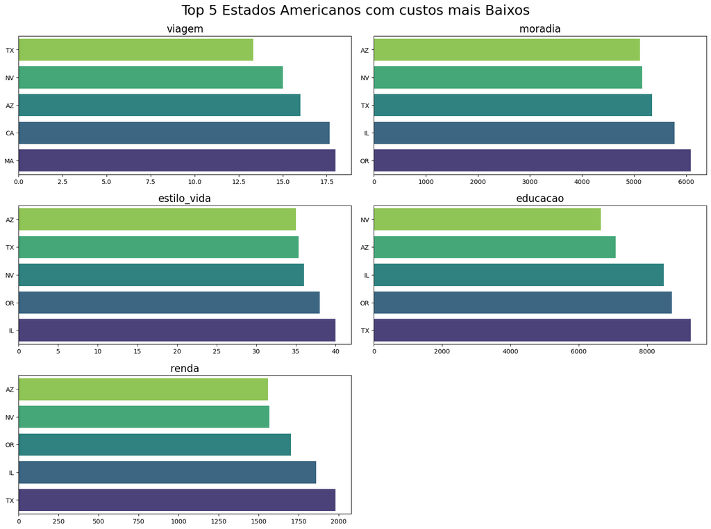

```python
# Gráficos - Top 5 países com maiores custos médios por categoria
colunas = usa.columns[5:]
plt.figure(figsize=(16,12))
plt.suptitle('Top 5 Estados Americanos com custos mais Baixos', size=22)

for n, col in enumerate(colunas):
    plt.subplot(3,2,n+1)
    current_df = usa[['States',col]].groupby('States').agg('mean').sort_values(by=col, ascending=True).reset_index().head(5)
    sns.barplot(y=current_df['States'].head(5), x=current_df[col], hue=current_df['States'].head(5), palette='viridis_r')
    plt.ylabel(None)
    plt.xlabel(None)
    plt.title(col, size=16)
plt.tight_layout(pad=1.4)
plt.show()
```

Observação: A categoria RENDA não e um custo, é um provendo (média de ganhos)

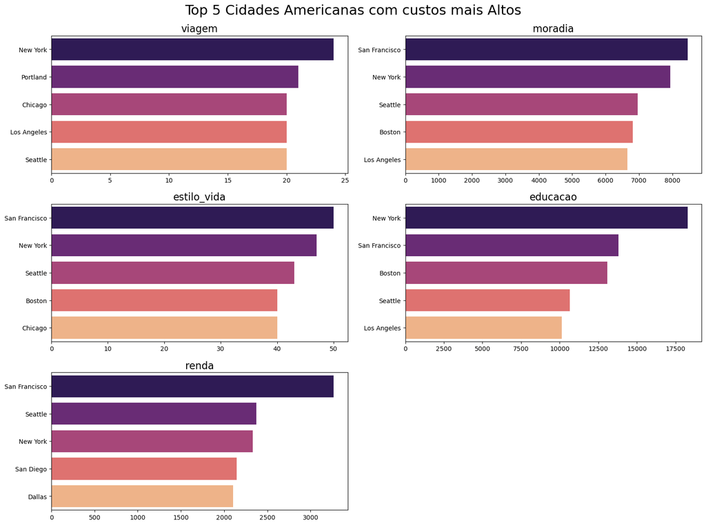

```python
# Gráficos - Top 5 países com maiores custos médios por categoria
colunas = usa.columns[5:]
plt.figure(figsize=(16,12))
plt.suptitle('Top 5 Cidades Americanas com custos mais Altos', size=22)

for n, col in enumerate(colunas):
    plt.subplot(3,2,n+1)
    current_df = usa[['Cities',col]].groupby('Cities').agg('mean').sort_values(by=col, ascending=False).reset_index().head(5)
    sns.barplot(y=current_df['Cities'].head(5), x=current_df[col], hue=current_df['Cities'].head(5), palette='magma')
    plt.ylabel(None)
    plt.xlabel(None)
    plt.title(col, size=16)
plt.tight_layout(pad=1.4)
plt.show()
```

Observação: A categoria RENDA não e um custo, é um provendo (média de ganhos)

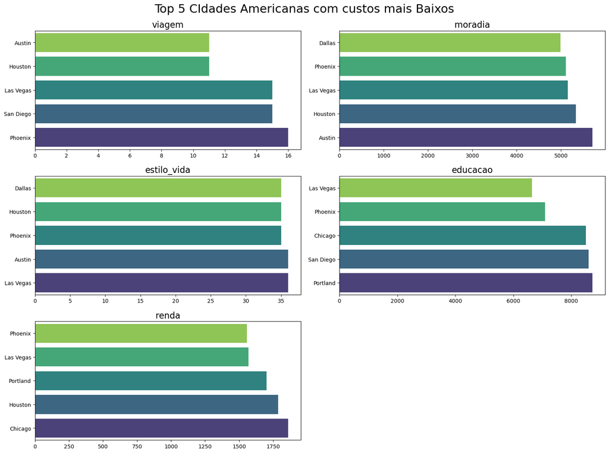

```python
# Gráficos - Top 5 países com maiores custos médios por categoria
colunas = usa.columns[5:]
plt.figure(figsize=(16,12))
plt.suptitle('Top 5 CIdades Americanas com custos mais Baixos', size=22)

for n, col in enumerate(colunas):
    plt.subplot(3,2,n+1)
    current_df = usa[['Cities',col]].groupby('Cities').agg('mean').sort_values(by=col, ascending=True).reset_index().head(5)
    sns.barplot(y=current_df['Cities'].head(5), x=current_df[col], hue=current_df['Cities'].head(5), palette='viridis_r')
    plt.ylabel(None)
    plt.xlabel(None)
    plt.title(col, size=16)
plt.tight_layout(pad=1.4)
plt.show()
```

Observação: A categoria RENDA não e um custo, é um provendo (média de ganhos)

#### Para termos uma noção melhor dessa variação nos custos, abaixo apresentamos alguns produtos e seu valor máximo e mínimo registrado no conjunto de dados.

```python
selecao = city[['Milk (regular), (1 liter)',
                'Water (0.33 liter bottle) ',
                'Potato (1kg)','Apartment (1 bedroom) in City Centre',
                'McMeal at McDonalds (or Equivalent Combo Meal)',
                'Internet (60 Mbps or More, Unlimited Data, Cable/ADSL)',
                'Apartment (1 bedroom) in City Centre',
                'Toyota Corolla 1.6l 97kW Comfort (Or Equivalent New Car)',
                'Gasoline (1 liter)',
                'Basic (Electricity, Heating, Cooling, Water, Garbage) for 85m2 Apartment',
                'Average Monthly Net Salary (After Tax)']]
```

```python
minimo = selecao.min()
maximo = selecao.max()
df_min = pd.DataFrame(minimo).T
df_max = pd.DataFrame(maximo).T
comparativo = pd.concat([df_min, df_max], axis=0).T
comparativo.columns = ['Min','Max']
comparativo
```

|  | Min | Max |
| --- | --- | --- |
| Milk (regular), (1 liter) | 0.39 | 2.64 |
| Water (0.33 liter bottle) | 0.14 | 3.21 |
| Potato (1kg) | 0.26 | 3.81 |
| Apartment (1 bedroom) in City Centre | 138.31 | 3131.06 |
| McMeal at McDonalds (or Equivalent Combo Meal) | 2.67 | 12.97 |
| Internet (60 Mbps or More, Unlimited Data, Cable/ADSL) | 4.44 | 93.29 |
| Apartment (1 bedroom) in City Centre | 138.31 | 3131.06 |
| Toyota Corolla 1.6l 97kW Comfort (Or Equivalent New Car) | 11163.69 | 67345.1 |
| Gasoline (1 liter) | 0.39 | 1.96 |
| Basic (Electricity, Heating, Cooling, Water, Garbage) for 85m2 Apartment | 18.56 | 265.52 |
| Average Monthly Net Salary (After Tax) | 163.94 | 6532.21 |

#### Descobrindo por cidades onde cada produto selecionado é mais caro e mais parato (TOP 5)

```python
itens = comparativo.index.to_list()
for i in itens:

    print(city[['Cities',i]]\
    .groupby(i)\
    .max().sort_values(by=i, ascending=False).head(5))
```

```
                                         Cities
Milk (regular), (1 liter)
2.64                             Taipei, Taiwan
2.54                       Hong Kong, Hong Kong
2.39                            Shanghai, China
2.04                       Singapore, Singapore
1.95                         Seoul, South Korea
                                         Cities
Water (0.33 liter bottle)
3.21                        Zurich, Switzerland
2.51                               Oslo, Norway
2.44                            Munich, Germany
2.22                        Copenhagen, Denmark
2.19                              Paris, France
                                        Cities
Potato (1kg)
3.81               New York, NY, United States
3.80                        Seoul, South Korea
3.49          San Francisco, CA, United States
3.20                              Tokyo, Japan
2.75                       Zurich, Switzerland
                                                                Cities
Apartment (1 bedroom) in City Centre
3131.06                               San Francisco, CA, United States
2854.26                                    New York, NY, United States
2275.95                                      Boston, MA, United States
2041.88                                           Hong Kong, Hong Kong
2015.24                                         London, United Kingdom
                                                               Cities
McMeal at McDonalds (or Equivalent Combo Meal)
12.97                                               Jerusalem, Israel
12.95                                           Tel Aviv-Yafo, Israel
12.94                                             Zurich, Switzerland
11.64                                              Reykjavik, Iceland
11.12                                                    Oslo, Norway
                                                                             Cities
Internet (60 Mbps or More, Unlimited Data, Cabl...
93.29                                               Abu Dhabi, United Arab Emirates
90.42                                                   Dubai, United Arab Emirates
78.31                                                                   Doha, Qatar
```

[output cut: 22 more lines]

```
1.64                 Tel Aviv-Yafo, Israel
                                                                 Cities
Basic (Electricity, Heating, Cooling, Water, Ga...
265.52                                               Frankfurt, Germany
242.66                                                  Munich, Germany
232.62                                                 Hamburg, Germany
231.80                                                  Berlin, Germany
199.61                                              Ljubljana, Slovenia
                                                                  Cities
Average Monthly Net Salary (After Tax)
6532.21                                 San Francisco, CA, United States
5714.80                                              Zurich, Switzerland
4741.65                                       Seattle, WA, United States
4665.46                                      New York, NY, United States
4293.13                                     San Diego, CA, United States
```

```python
for i in itens:

    print(city[['Cities',i]]\
    .groupby(i)\
    .max().sort_values(by=i, ascending=True).head(5))
```

```
                                               Cities
Milk (regular), (1 liter)
0.39                                   Tunis, Tunisia
0.50                                   Kolkata, India
0.51                       Phoenix, AZ, United States
0.53                                 Bangalore, India
0.55                                     Lodz, Poland
                                      Cities
Water (0.33 liter bottle)
0.14                          Kolkata, India
0.17                            Noida, India
0.18                        Tbilisi, Georgia
0.19                            Delhi, India
0.20                        Kathmandu, Nepal
                        Cities
Potato (1kg)
0.26              Noida, India
0.27            Kolkata, India
0.28          Ahmedabad, India
0.29              Delhi, India
0.30            Gurgaon, India
                                                 Cities
Apartment (1 bedroom) in City Centre
138.31                                   Kolkata, India
142.04                                Alexandria, Egypt
149.06                                Chandigarh, India
153.28                                     Noida, India
155.63                                 Kathmandu, Nepal
                                                               Cities
McMeal at McDonalds (or Equivalent Combo Meal)
2.67                                              Manila, Philippines
2.70                                             Tashkent, Uzbekistan
3.00                                            Podgorica, Montenegro
3.06                                                    Izmir, Turkey
3.16                                                      Pune, India
                                                              Cities
Internet (60 Mbps or More, Unlimited Data, Cabl...
4.44                                                   Lviv, Ukraine
5.11                                                   Kiev, Ukraine
5.57                                                Kharkiv, Ukraine
```

[output cut: 22 more lines]

```
0.48                           Doha, Qatar
                                                                 Cities
Basic (Electricity, Heating, Cooling, Water, Ga...
18.56                                                 Alexandria, Egypt
21.79                                                  Hyderabad, India
22.24                                                  Bangalore, India
22.64                                               Guadalajara, Mexico
24.92                                                  Kathmandu, Nepal
                                                      Cities
Average Monthly Net Salary (After Tax)
163.94                                     Alexandria, Egypt
184.17                                      Kathmandu, Nepal
205.98                                  Tashkent, Uzbekistan
221.70                                          Cairo, Egypt
244.23                                    Colombo, Sri Lanka
```

### Vamos calcular os Top 5 locais com maior indice de Custo de Vida geral.

```python
X = city[['estilo_vida', 'alimento', 'moradia', 'educacao', 'viagem', 'renda']]
scaler = MinMaxScaler()
dados = scaler.fit_transform(X)
dados = pd.DataFrame(dados)
dados.columns = X.columns
dados.head()
```

|  | estilo_vida | alimento | moradia | educacao | viagem | renda |
| --- | --- | --- | --- | --- | --- | --- |
| 0 | 0.38 | 0.166667 | 0.139081 | 0.139097 | 0.222222 | 0.074890 |
| 1 | 0.14 | 0.166667 | 0.161530 | 0.177959 | 0.166667 | 0.043109 |
| 2 | 0.08 | 0.166667 | 0.155125 | 0.121178 | 0.111111 | 0.036816 |
| 3 | 0.58 | 0.500000 | 0.252482 | 0.032478 | 0.527778 | 0.346444 |
| 4 | 0.32 | 0.000000 | 0.082583 | 0.057565 | 0.055556 | 0.018250 |

```python
dados['indice_life_cost'] = (dados['alimento'] + dados['estilo_vida'] +
                            dados['moradia'] + dados['educacao'] +
                            dados['viagem'] + dados['renda']) / 6
cities = city['Cities']
dados= pd.concat([cities, dados], axis=1)
dados[['Cities', 'indice_life_cost']].sort_values(by='indice_life_cost', ascending=False).head(5).reset_index(drop=True)
```

|  | Cities | indice_life_cost |
| --- | --- | --- |
| 0 | Zurich, Switzerland | 0.798264 |
| 1 | New York, NY, United States | 0.692293 |
| 2 | San Francisco, CA, United States | 0.658973 |
| 3 | London, United Kingdom | 0.572505 |
| 4 | Singapore, Singapore | 0.567523 |

```python
dados[['Cities', 'indice_life_cost']].sort_values(by='indice_life_cost', ascending=True).head(5).reset_index(drop=True)
```

|  | Cities | indice_life_cost |
| --- | --- | --- |
| 0 | Kolkata, India | 0.018756 |
| 1 | Chennai, India | 0.032182 |
| 2 | Hyderabad, India | 0.036649 |
| 3 | Noida, India | 0.049466 |
| 4 | Ahmedabad, India | 0.052240 |

Com base nos dados coletados as TOP 5 cidades com custo mais elevados no mundo seriam:

- **Zurich**
- New York
- San Francisco
- London
- Singapore

E as cidades com menos custo de vida, as TOP 5, estão todas na Índia:

- Kolkata
- Chennai
- Hyderabad
- Noida
- Ahmedabad

```python
quallitylife = pd.read_csv('movehubqualityoflife.csv')
quallitylife = pd.concat([quallitylife['City'], quallitylife.iloc[:,2:].astype('int')], axis=1)
quallitylife.head()
```

|  | City | Purchase Power | Health Care | Pollution | Quality of Life | Crime Rating |
| --- | --- | --- | --- | --- | --- | --- |
| 0 | Caracas | 11 | 44 | 83 | 8 | 85 |
| 1 | Johannesburg | 53 | 59 | 47 | 51 | 83 |
| 2 | Fortaleza | 52 | 45 | 66 | 36 | 78 |
| 3 | Saint Louis | 80 | 77 | 31 | 87 | 78 |
| 4 | Mexico City | 24 | 61 | 18 | 27 | 77 |

```python
dados['cid'] = dados['Cities'].map(lambda x: x.split(', ')[0])
dados['indice_life_cost'] = round(dados['indice_life_cost'], 2)
top_cities = pd.merge(quallitylife, dados, how='inner', left_on='City', right_on=dados['cid'])
top_cities = top_cities[['City','indice_life_cost','Pollution', 'Health Care', 'Crime Rating', 'Quality of Life']]
```

```python
print("Top 5 Cidades com a menor taxa de criminalidade")
top_cities[['City','indice_life_cost','Crime Rating']].sort_values(by=['Crime Rating','indice_life_cost'], ascending=[True, False]).head(5).reset_index(drop=True)
```

```
Top 5 Cidades com a menor taxa de criminalidade
```

|  | City | indice_life_cost | Crime Rating |
| --- | --- | --- | --- |
| 0 | Abu Dhabi | 0.34 | 10 |
| 1 | Tokyo | 0.45 | 13 |
| 2 | Zurich | 0.80 | 15 |
| 3 | Munich | 0.39 | 15 |
| 4 | Taipei | 0.31 | 15 |

```python
print("Top 5 Cidades com a menor taxa de poluição")
top_cities[['City','indice_life_cost','Pollution']].sort_values(by=['Pollution','indice_life_cost'], ascending=[True, True]).head(5).reset_index(drop=True)
```

```
Top 5 Cidades com a menor taxa de poluição
```

|  | City | indice_life_cost | Pollution |
| --- | --- | --- | --- |
| 0 | Montreal | 0.31 | 6 |
| 1 | Brussels | 0.41 | 6 |
| 2 | Toronto | 0.44 | 8 |
| 3 | Adelaide | 0.34 | 12 |
| 4 | New York | 0.69 | 12 |

```python
print("Top 5 Cidades com a maior taxa de assistência em saúde")
top_cities[['City','indice_life_cost','Health Care']].sort_values(by=['Health Care','indice_life_cost'], ascending=[False, True]).head(5).reset_index(drop=True)
```

```
Top 5 Cidades com a maior taxa de assistência em saúde
```

|  | City | indice_life_cost | Health Care |
| --- | --- | --- | --- |
| 0 | Bangkok | 0.28 | 95 |
| 1 | Taipei | 0.31 | 88 |
| 2 | Munich | 0.39 | 88 |
| 3 | Brisbane | 0.40 | 88 |
| 4 | Oslo | 0.55 | 88 |

```python
print("Top 5 Cidades com a maior taxa de qualidade de vida")
top_cities[['City','indice_life_cost','Quality of Life']].sort_values(by=['Quality of Life','indice_life_cost'], ascending=[False, True]).head(5).reset_index(drop=True)
```

```
Top 5 Cidades com a maior taxa de qualidade de vida
```

|  | City | indice_life_cost | Quality of Life |
| --- | --- | --- | --- |
| 0 | Zurich | 0.80 | 97 |
| 1 | Adelaide | 0.34 | 91 |
| 2 | Berlin | 0.34 | 91 |
| 3 | Munich | 0.39 | 90 |
| 4 | Edmonton | 0.30 | 89 |

### Conclusão

Mesmo Zurich sendo a cidade como maior custo de vida no mundo ela proporciona uma qualidade de vida muito boa. Seguida por Adelaide na Austrália que conta com o segundo lugar em qualidade de vida e o custo caindo para menos da métade em relação ao primeiro colocado. Adelaide também conta com um dos 5 menores índices de baixa poluição do mundo e Zurich na décima sétima colocação.

Munich aparece entre as TOP 5 cidades no mundo nos quesitos de qualidade de Vida, baixa criminalidade e boa assistência em saúde, além de ter um custo de vida mais próximo à cidade de Adelaide.

Cabe uma avaliação profunda e pessoal em relação a quais os fatores mais importantes de cada um para classificar a melhor cidade para viver.